# **Introduction**

# **Step 6a): Pseudocode for the UCB Algorithm**

```
ALGORITHM: UpperConfidenceBound

INPUT:
  - A list of all available arms (stocks), let's call it `arms`.
  - The total number of time steps (trading days), `T`.
  - An exploration parameter, `c`.

INITIALIZE:
  - For each arm `a` in `arms`:
    - Create a counter for the number of times `a` is selected: `counts[a] = 0`
    - Create a variable for the sum of rewards from `a`: `sum_rewards[a] = 0`
  - Create a list to store the history of chosen arms: `chosen_arms_history`

PROCEDURE:
  // Main loop that runs for each time step (day) from 1 to T
  FOR t = 1 TO T:
    // --- ACTION SELECTION ---
    // If there is any arm that has not been tried yet, select it.
    // This ensures each arm is sampled at least once.
    IF there is an arm `a` where `counts[a] == 0`:
      chosen_arm = that arm `a`
    ELSE:
      // If all arms have been tried, calculate the UCB score for each arm.
      FOR each arm `a` in `arms`:
        // Exploitation part: Calculate the average reward for arm `a`.
        average_reward = sum_rewards[a] / counts[a]

        // Exploration part: Calculate the uncertainty bonus.
        uncertainty_bonus = c * SQRT(LOG(t) / counts[a])

        // The UCB score is the sum of the two parts.
        ucb_score[a] = average_reward + uncertainty_bonus

      // Select the arm with the highest UCB score.
      chosen_arm = the arm `a` that maximizes `ucb_score[a]`

    // --- OBSERVE REWARD AND UPDATE ---
    // Play the chosen_arm and observe the resulting reward.
    reward = get_reward(chosen_arm, t)

    // Update the statistics for the chosen arm.
    counts[chosen_arm] = counts[chosen_arm] + 1
    sum_rewards[chosen_arm] = sum_rewards[chosen_arm] + reward

    // Record the chosen arm for this time step.
    APPEND chosen_arm to `chosen_arms_history`

END FOR
```

# **Step 6b: Python Implementation of the UCB Algorithm**

```
Starting UCB Simulation with exploration parameter c = 2.0
Simulation Complete. Final Cumulative Reward: -0.5348
```

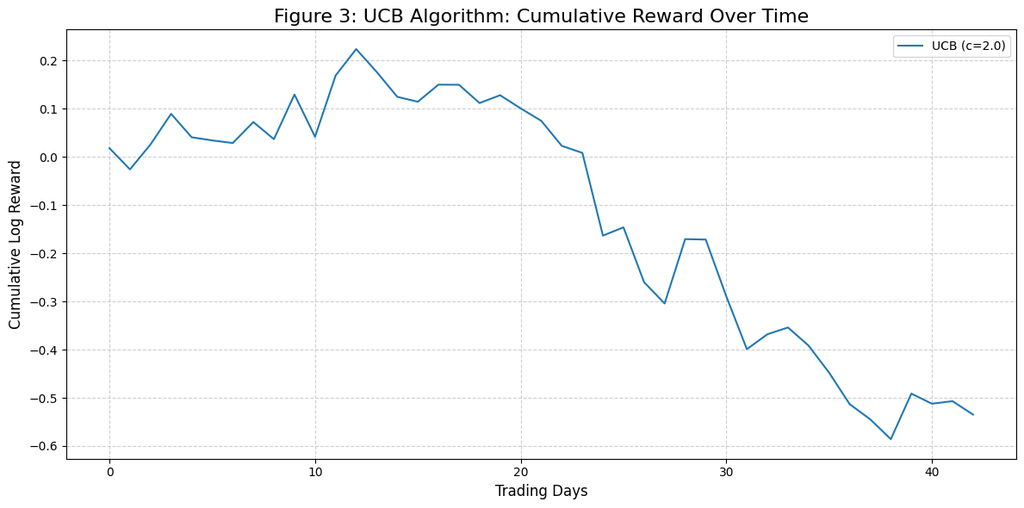

```python
import pandas as pd
import numpy as np
import matplotlib.pyplot as plt
import math

# =============================================================================
# 1) DATA LOADING & PREPARATION
# =============================================================================
csv_url = (
    "https://docs.google.com/spreadsheets/"
    "d/12d6YzmR1eDi-XXAHJe73xPc6ciitdp8I/"
    "export?format=csv"
)
try:
    df_prices = pd.read_csv(csv_url)
except Exception as e:
    print(f"Error loading data from URL: {e}")
    print("Attempting to load from local file 'graphData.xlsx - Sheet2.csv'...")
    try:
        df_prices = pd.read_csv("graphData.xlsx - Sheet2.csv")
    except FileNotFoundError:
        print("Local file not found. Please ensure the data file is available.")
        exit()

df_prices.rename(columns={df_prices.columns[0]: "Date"}, inplace=True)
df_prices["Date"] = pd.to_datetime(df_prices["Date"], errors="coerce")


prices = df_prices.set_index("Date").apply(pd.to_numeric, errors="coerce")
df_returns = np.log(prices / prices.shift(1)).dropna(how="all")

# =============================================================================
# 2) UCB ALGORITHM IMPLEMENTATION (STEP 6b)
# =============================================================================
def run_ucb_simulation(returns_df, c):
    """
    Implements the UCB algorithm based on the pseudocode from Step 6a.

    Args:
        returns_df (pd.DataFrame): DataFrame of daily log returns (arms' rewards).
        c (float): The exploration parameter controlling the confidence bound.

    Returns:
        tuple: Contains the final cumulative reward and the history of rewards over time.
    """
    num_days, num_arms = returns_df.shape
    arms = returns_df.columns.tolist()

    counts = {arm: 0 for arm in arms}
    sum_rewards = {arm: 0.0 for arm in arms}

    total_reward = 0.0
    cumulative_rewards_history = []

    print(f"Starting UCB Simulation with exploration parameter c = {c}")

    for t in range(num_days):
        chosen_arm = None

        if t < num_arms:
            chosen_arm = arms[t]
        else:
            ucb_scores = {}
            for arm in arms:

                average_reward = sum_rewards[arm] / counts[arm]

                """Exploration Term: the uncertainty bonus."""
                uncertainty_bonus = c * math.sqrt(math.log(t) / counts[arm])

                """UCB score is the sum of the two terms."""
                ucb_scores[arm] = average_reward + uncertainty_bonus

            chosen_arm = max(ucb_scores, key=ucb_scores.get)


        reward = returns_df.loc[returns_df.index[t], chosen_arm]

        counts[chosen_arm] += 1
        sum_rewards[chosen_arm] += reward

        total_reward += reward
        cumulative_rewards_history.append(total_reward)

    print(f"Simulation Complete. Final Cumulative Reward: {total_reward:.4f}")
    return total_reward, cumulative_rewards_history

# =============================================================================
# 3) EXECUTION AND VISUALIZATION
# =============================================================================
if __name__ == "__main__":

    EXPLORATION_PARAM = 2.0

    final_reward, rewards_history = run_ucb_simulation(
        returns_df=df_returns,
        c=EXPLORATION_PARAM
    )

    plt.figure(figsize=(12, 6))
    plt.plot(rewards_history, label=f'UCB (c={EXPLORATION_PARAM})')
    plt.title('Figure 3: UCB Algorithm: Cumulative Reward Over Time', fontsize=16)
    plt.xlabel('Trading Days', fontsize=12)
    plt.ylabel('Cumulative Log Reward', fontsize=12)
    plt.grid(True, linestyle='--', alpha=0.6)
    plt.legend()
    plt.tight_layout()
    plt.show()
```

# **Step 6c: Commented Code and Application**

The code implemented in Step 6b follows this procedure:

- First, the raw daily price data for all 30 stocks is loaded from the `graphData.xlsx` file into a pandas DataFrame. The data is cleaned by ensuring the date column is correctly named and formatted. From this price data, the daily *logarithmic returns* are calculated for each stock using the formula: $R_{i,t} = \ln\left(\frac{P_{i,t}}{P_{i,t-1}}\right)$

This creates a new DataFrame where each column represents a single stock (an "arm") and each row contains the reward (the return) for a specific day. This returns DataFrame is the primary input for the algorithm.

**UCB Algorithm Implementation**

The core logic is contained within a single function that executes the UCB simulation. The procedure inside this function is as follows:

- Initialization: Dictionaries are created to keep track of the number of times each arm has been selected ($N_t(a)$) and the sum of rewards received from each arm.
- Simulation Loop: The algorithm iterates through each trading day.
  - Initial Exploration: For the first 30 days, each stock is selected exactly once. This is a crucial step to ensure there is an initial reward estimate for every arm, which prevents division-by-zero errors in the main UCB calculation.
  - Action Selection: For all subsequent days, the agent calculates a UCB score for every stock by applying the formula: $A_t = \underset{a}{\operatorname{argmax}} \left[ Q_t(a) + c \sqrt{\frac{\ln t}{N_t(a)}} \right]$ Here, the exploitation term $Q_t(a)$ is the average reward observed so far, and the exploration term is the uncertainty bonus that encourages trying less-frequently chosen stocks. The stock with the highest combined score is selected for that day.
  - Update: After selecting a stock, the agent observes its historical return for that day. It then updates its internal records by incrementing the selection count ($N_t(a)$) and adding the new reward to the sum of rewards for the chosen stock.

**Application and Visualization**

Finally, the main part of the script applies this UCB function to the prepared dataset. It sets the exploration parameter `c` and runs the simulation. The output a history of the cumulative reward over time is then plotted using Matplotlib to generate a line chart that visually represents the algorithm's performance.

```
Starting UCB Simulation with exploration parameter c = 2.0
Simulation Complete. Final Cumulative Reward: -0.5348
```

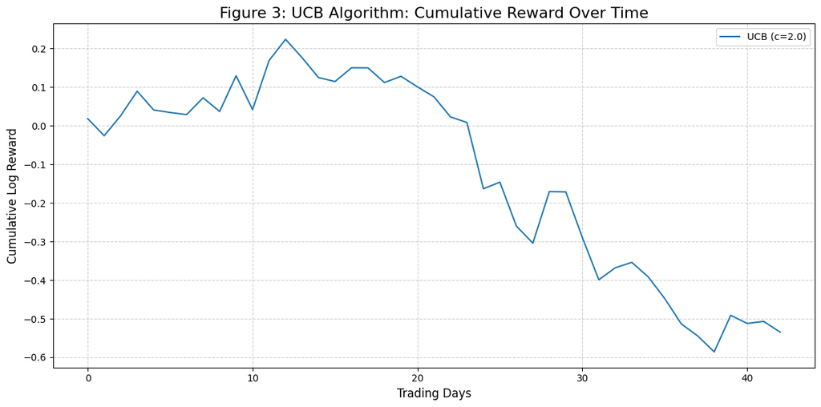

```python
import pandas as pd
import numpy as np
import matplotlib.pyplot as plt
import math


# =============================================================================
# 1) DATA LOADING & PREPARATION
# =============================================================================
csv_url = (
    "https://docs.google.com/spreadsheets/"
    "d/12d6YzmR1eDi-XXAHJe73xPc6ciitdp8I/"
    "export?format=csv"
)
try:
    df_prices = pd.read_csv(csv_url)
except Exception as e:
    print(f"Error loading data from URL: {e}")
    print("Attempting to load from local file 'graphData.xlsx - Sheet2.csv'...")
    try:
        df_prices = pd.read_csv("graphData.xlsx - Sheet2.csv")
    except FileNotFoundError:
        print("Local file not found. Please ensure the data file is available.")
        exit()

df_prices.rename(columns={df_prices.columns[0]: "Date"}, inplace=True)
df_prices["Date"] = pd.to_datetime(df_prices["Date"], errors="coerce")


prices = df_prices.set_index("Date").apply(pd.to_numeric, errors="coerce")
df_returns = np.log(prices / prices.shift(1)).dropna(how="all")


# =============================================================================
# 2) UCB ALGORITHM IMPLEMENTATION (WITH DETAILED COMMENTS)
# =============================================================================
def run_ucb_simulation(returns_df, c):
    """
    Implements the UCB algorithm and applies it to the stock return data.

    Args:
        returns_df (pd.DataFrame): DataFrame where each column is an "arm" (stock)
                                   and each row is a time step (day).
        c (float): The exploration parameter that tunes the confidence bound.

    Returns:
        tuple: Contains the final reward and the history of cumulative rewards.
    """

    """
    --- Initialization ---
    Get the dimensions of the problem: number of days and number of arms (stocks).
    """
    num_days, num_arms = returns_df.shape
    arms = returns_df.columns.tolist()

    """
    Initialize statistics for each arm.
    N_t(a): Tracks the number of times each arm has been selected.
    This will store the sum of rewards for each arm, used to calculate the average.
    """
    counts = {arm: 0 for arm in arms}
    sum_rewards = {arm: 0.0 for arm in arms}

    """
    Initialize variables to track the simulation's performance.
    """
    total_reward = 0.0
    cumulative_rewards_history = []

    print(f"Starting UCB Simulation with exploration parameter c = {c}")


    """
    --- Main Simulation Loop ---
    Iterate through each day of the investment period.
    """
    for t in range(num_days):
        chosen_arm = None

        """
        --- Action Selection using UCB formula ---
        For the first `num_arms` days, select each arm once.
        This is a crucial step to get an initial reward estimate for every arm,
        preventing a division-by-zero error in the bonus calculation.
        """
        if t < num_arms:
            chosen_arm = arms[t]
        else:
            ucb_scores = {}

            """
            For all subsequent days, calculate the UCB score for each arm.
            """
            for arm in arms:

                """
                Exploitation Term (Q_t(a)): The average reward observed from this arm so far.
                """
                average_reward = sum_rewards[arm] / counts[arm]


                """
                Exploration Term (Uncertainty Bonus): This term is larger for arms
                that have been selected fewer times, encouraging exploration.
                Corresponds to: c * sqrt(ln(t) / N_t(a))
                """
                uncertainty_bonus = c * math.sqrt(math.log(t) / counts[arm])


                """
                The final UCB score balances known performance with uncertainty.
                """
                ucb_scores[arm] = average_reward + uncertainty_bonus


            """
            Select the arm with the highest UCB score (argmax).
            """
            chosen_arm = max(ucb_scores, key=ucb_scores.get)


        """
        --- Observe Reward and Update ---
        Get the actual historical return for the chosen stock on the current day.
        """
        reward = returns_df.loc[returns_df.index[t], chosen_arm]


        """
        Update the statistics for the arm that was just played.
        """
        counts[chosen_arm] += 1
        sum_rewards[chosen_arm] += reward


        """
        Record the performance for this day.
        """
        total_reward += reward
        cumulative_rewards_history.append(total_reward)

    print(f"Simulation Complete. Final Cumulative Reward: {total_reward:.4f}")
    return total_reward, cumulative_rewards_history

# =============================================================================
# 3) APPLICATION TO THE DATASET
# =============================================================================
if __name__ == "__main__":

    """
    Set the exploration parameter 'c'. A value of 2 is a common standard.
    """
    EXPLORATION_PARAM = 2.0

    """
    Apply the UCB algorithm to the daily returns data.
    """
    final_reward, rewards_history = run_ucb_simulation(
        returns_df=df_returns,
        c=EXPLORATION_PARAM
    )


    """
    --- Visualize the Results of the Application ---
    """
    plt.figure(figsize=(12, 6))
    plt.plot(rewards_history, label=f'UCB (c={EXPLORATION_PARAM})')
    plt.title('Figure 3: UCB Algorithm: Cumulative Reward Over Time', fontsize=16)
    plt.xlabel('Trading Days', fontsize=12)
    plt.ylabel('Cumulative Log Reward', fontsize=12)
    plt.grid(True, linestyle='--', alpha=0.6)
    plt.legend()
    plt.tight_layout()

    """
    Save the resulting plot to a file.
    """
    plt.savefig('ucb_cumulative_reward.png')

    plt.show()
```

# **Step 7: Epsilon-greedy (ε-greedy) policy**

The epsilon-greedy algorithm is a simple yet effective strategy for balancing exploration and exploitation in reinforcement learning. On every single time step, the algorithm makes a choice based on a predefined probability, epsilon (ε), which is a small number typically between 0 and 0.1.

The logic is as follows:

- With a high probability of (1 - ε), the algorithm chooses to exploit. It acts greedily by selecting the action (the "arm") that has the highest estimated value based on past experience.
- With a small probability of ε, the algorithm chooses to explore. It ignores the current best option and instead picks an arm completely at random from all available options.

This process ensures that the agent primarily exploits its knowledge of the best-performing options but occasionally takes a random step to explore the environment. This exploration is crucial for discovering potentially better actions and improving the agent's estimates of other arms' values (Sutton and Barto 28).

The epsilon (ε) parameter is the single knob you can tune to control the algorithm's behavior.

- A higher ε (e.g., 0.2) means the agent will explore more often (20% of the time).
- A lower ε (e.g., 0.05) means the agent will be greedier and explore less often (5% of the time).
- If ε = 0, the algorithm is purely greedy and will never explore, risking getting stuck with a suboptimal choice.

> **Comparison to UCB**

The key difference between ε-greedy and Upper Confidence Bound (UCB) lies in the intelligence of their exploration strategies.

- Epsilon-Greedy's exploration is undirected. When it decides to explore, it chooses among all arms (even bad ones) with equal probability.
- UCB's exploration is directed. It prioritizes exploring arms that are either promising (have high average rewards) or highly uncertain (have not been tried often), a principle often described as "optimism in the face of uncertainty" (Auer et al. 236).

Because of this, UCB is often more sample-efficient, meaning it can find the best arm faster in many situations. However, epsilon-greedy is extremely simple to understand and implement, making it a very common and powerful baseline strategy in reinforcement learning.

# **Step 8a: Pseudocode for the Epsilon-Greedy Algorithm**

```
ALGORITHM: EpsilonGreedy

INPUT:
  - A list of all available arms (stocks), `arms`.
  - The total number of time steps (trading days), `T`.
  - An exploration probability, `epsilon` (e.g., 0.1).

INITIALIZE:
  - For each arm `a` in `arms`:
    - Create a counter for the number of times `a` is selected: `counts[a] = 0`
    - Create a variable for the sum of rewards from `a`: `sum_rewards[a] = 0`

PROCEDURE:
  // Main loop that runs for each time step from 1 to T
  FOR t = 1 TO T:
    // --- ACTION SELECTION: EXPLORE OR EXPLOIT ---
    Generate a random number `p` between 0 and 1.

    IF p < epsilon:
      // EXPLORE: With probability epsilon, choose an arm at random.
      chosen_arm = select a random arm from `arms`.
    ELSE:
      // EXPLOIT: With probability 1-epsilon, choose the best-known arm.
      // First, check if there are any arms that have never been tried.
      untried_arms = find all arms `a` where `counts[a] == 0`.

      IF untried_arms is not empty:
        // If there are untried arms, pick one of them to ensure all arms are sampled.
        chosen_arm = select a random arm from `untried_arms`.
      ELSE:
        // If all arms have been tried, find the arm with the highest average reward.
        FOR each arm `a` in `arms`:
          average_reward[a] = sum_rewards[a] / counts[a]

        // This is the greedy action.
        chosen_arm = the arm `a` that maximizes `average_reward[a]`.

    // --- OBSERVE REWARD AND UPDATE ---
    // Play the chosen_arm and observe the resulting reward for the current day `t`.
    reward = get_reward(chosen_arm, t)

    // Update the statistics for the chosen arm.
    counts[chosen_arm] = counts[chosen_arm] + 1
    sum_rewards[chosen_arm] = sum_rewards[chosen_arm] + reward

  END FOR
```

# **Step 8b: Python Implementation of the Epsilon-Greedy Algorithm**

This code defines a function that contains the logic for the epsilon-greedy algorithm and then applies it to your dataset. The output is a plot showing the cumulative reward over the investment period, which visualizes the algorithm's performance.

```
Starting Epsilon-Greedy Simulation with epsilon = 0.1
Simulation Complete. Final Cumulative Reward: 0.2645
```

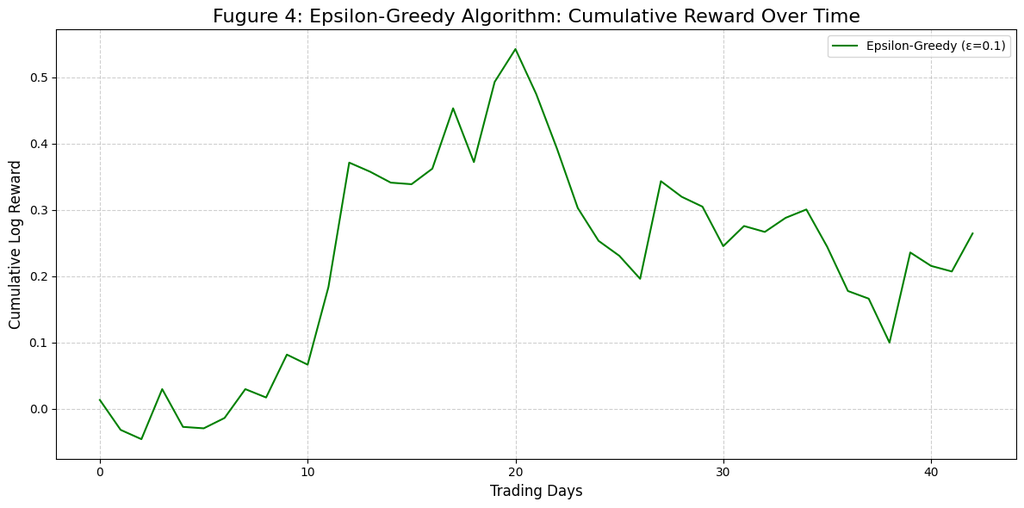

```python
import pandas as pd
import numpy as np
import matplotlib.pyplot as plt
import random

np.random.seed(42)
# =============================================================================
# 1) DATA LOADING & PREPARATION
# =============================================================================
csv_url = (
    "https://docs.google.com/spreadsheets/"
    "d/12d6YzmR1eDi-XXAHJe73xPc6ciitdp8I/"
    "export?format=csv"
)
try:
    df_prices = pd.read_csv(csv_url)
except Exception as e:
    print(f"Error loading data from URL: {e}")
    print("Attempting to load from local file 'graphData.xlsx - Sheet2.csv'...")
    try:
        df_prices = pd.read_csv("graphData.xlsx - Sheet2.csv")
    except FileNotFoundError:
        print("Local file not found. Please ensure the data file is available.")
        exit()

df_prices.rename(columns={df_prices.columns[0]: "Date"}, inplace=True)
df_prices["Date"] = pd.to_datetime(df_prices["Date"], errors="coerce")


prices = df_prices.set_index("Date").apply(pd.to_numeric, errors="coerce")
df_returns = np.log(prices / prices.shift(1)).dropna(how="all")
# =============================================================================
# 2) EPSILON-GREEDY ALGORITHM IMPLEMENTATION (STEP 8b)
# =============================================================================
def run_epsilon_greedy_simulation(returns_df, epsilon):
    """
    Implements the Epsilon-Greedy algorithm based on the pseudocode from Step 8a.

    Args:
        returns_df (pd.DataFrame): DataFrame of daily log returns (arms' rewards).
        epsilon (float): The probability of choosing to explore (must be between 0 and 1).

    Returns:
        tuple: Contains the final cumulative reward and the history of rewards over time.
    """
    # --- Initialization ---
    num_days, num_arms = returns_df.shape
    arms = returns_df.columns.tolist()

    """
    Initialize statistics for each arm:
    - counts: N_t(a), tracks the number of times each arm has been selected.
    - sum_rewards: Used to calculate the average reward (Q_t(a)).
    """
    counts = {arm: 0 for arm in arms}
    sum_rewards = {arm: 0.0 for arm in arms}

    total_reward = 0.0
    cumulative_rewards_history = []

    print(f"Starting Epsilon-Greedy Simulation with epsilon = {epsilon}")

    # --- Main Simulation Loop ---
    for t in range(num_days):
        chosen_arm = None
        # --- Action Selection: Explore or Exploit ---
        if random.random() < epsilon:
            """
            EXPLORE: With probability epsilon, choose a random arm.
            """
            chosen_arm = random.choice(arms)
        else:
            """
            EXPLOIT: With probability 1-epsilon, choose the best-known arm.
            """
            # First, check for any arms that have never been tried to ensure
            # all get sampled at least once before true exploitation begins.
            untried_arms = [arm for arm in arms if counts[arm] == 0]
            if untried_arms:
                chosen_arm = random.choice(untried_arms)
            else:
                # If all arms have been tried, find the one with the best average reward.
                avg_rewards = {arm: sum_rewards[arm] / counts[arm] for arm in arms}
                chosen_arm = max(avg_rewards, key=avg_rewards.get)

        # --- Observe Reward and Update ---
        reward = returns_df.loc[returns_df.index[t], chosen_arm]

        counts[chosen_arm] += 1
        sum_rewards[chosen_arm] += reward

        total_reward += reward
        cumulative_rewards_history.append(total_reward)

    print(f"Simulation Complete. Final Cumulative Reward: {total_reward:.4f}")
    return total_reward, cumulative_rewards_history

# =============================================================================
# 3) APPLICATION TO THE DATASET
# =============================================================================
if __name__ == "__main__":

    """
    Set the exploration parameter 'epsilon'. A value of 0.1 means the agent
    will explore 10% of the time and exploit 90% of the time.
    """
    EPSILON_PARAM = 0.1

    """
    Apply the Epsilon-Greedy algorithm to the daily returns data.
    """
    final_reward, rewards_history = run_epsilon_greedy_simulation(
        returns_df=df_returns,
        epsilon=EPSILON_PARAM
    )

    """
    --- Visualize the Results of the Application ---
    """
    plt.figure(figsize=(12, 6))
    plt.plot(rewards_history, label=f'Epsilon-Greedy (ε={EPSILON_PARAM})', color='green')
    plt.title('Fugure 4: Epsilon-Greedy Algorithm: Cumulative Reward Over Time', fontsize=16)
    plt.xlabel('Trading Days', fontsize=12)
    plt.ylabel('Cumulative Log Reward', fontsize=12)
    plt.grid(True, linestyle='--', alpha=0.6)
    plt.legend()
    plt.tight_layout()

    """
    Save the resulting plot to a file.
    """
    plt.savefig('epsilon_greedy_cumulative_reward.png')

    plt.show()
```

# **Step 8c) Comments of B’s code**

The code implemented in step 8b) works as a complete simulation of the epsilon-greedy algorithm applied to the stock market data. The procedure can be understood in three stages: data preparation, the core algorithm logic, and finally, the application and visualization of the results.

**Data Preparation**

The process begins by loading the raw daily price data, $P_{i,t}$ for each stock $i$ on day $t$, from the provided CSV file. This data is then cleaned to ensure the date column is correctly formatted for time-series analysis. The crucial transformation in this stage is the calculation of daily logarithmic returns for each of the 30 stocks using the formula: $$R_{i,t} = \ln\left(\frac{P_{i,t}}{P_{i,t-1}}\right)$$

This resulting table of returns serves as the environment for our simulation, where each stock is an "arm" and its return on any given day is the "reward" the agent receives for choosing it.

**Epsilon-Greedy Algorithm Logic**

The core of the implementation is a function that simulates the epsilon-greedy strategy day by day.

- Initialization: The procedure first initializes two key statistics for each stock $a$: a counter for the number of times it has been selected, $N_t(a)$, and the sum of rewards it has generated.
- Simulation Loop: The code then iterates through each trading day $t$. In each iteration, the agent decides which stock to select based on the epsilon-greedy rule:
  - Exploration: With a small probability epsilon ($\epsilon$), the agent chooses to explore. This is implemented by selecting a stock completely at random from the 30 available options.
  - Exploitation: With a high probability of $1-\epsilon$, the agent chooses to exploit. It acts greedily by selecting the stock with the highest current estimated average reward, $Q_t(a)$. This estimated reward is calculated as: $$Q_t(a) = \frac{\text{Sum of rewards from stock } a \text{ up to time } t}{N_t(a)}$$ The code includes a practical detail for the initial phase: if an arm has never been tried ($N_t(a) = 0$), it is prioritized during the exploitation step to ensure every stock is sampled at least once.
- Learning: After a stock is selected, its historical return for that day is observed. The agent then "learns" from this result by updating the selection count $N_t(a)$ and the sum of rewards for the chosen stock.

**Application and Visualization**

The final part of the script applies this logic. It sets a value for the hyperparameter **epsilon ($\epsilon$), such as 0.1 (representing a 10% chance of exploration). The simulation is then run on the entire dataset of returns. The code tracks the agent's performance by calculating the cumulative reward, $C_t = \sum_{i=1}^{t} r_i$, at the end of each day. This history of cumulative rewards is then used to generate a line plot, which provides a clear visual representation of the algorithm's performance over the entire investment period.